# R Code Chapter 4

Witold Wolski

December 23, 2016

# 4.4.1 Model building for the beetle data

```r
rm(list=ls())
getwd()
```

```
## [1] "C:/Users/wewol/Google Drive/Courses/Sheffield/MAS6003TaskSolutions"
```

```r
load("data/MAS367-GLMs.RData", envir = e <- new.env())
grep("beetle",names(e))
```

```
## [1] 8
```

## Fitting minimal model

```r
beetle<-e$beetle
lapply(beetle,class)
```

```
## $conc
## [1] "numeric"
##
## $number
## [1] "integer"
##
## $dead
## [1] "integer"
##
## $propn.dead
## [1] "numeric"
```

```r
head(beetle)
```

```
##     conc number dead propn.dead
## 1 1.6907     59    6  0.1016949
## 2 1.7242     60   13  0.2166667
## 3 1.7552     62   18  0.2903226
## 4 1.7842     56   28  0.5000000
## 5 1.8113     63   52  0.8253968
## 6 1.8369     59   53  0.8983051
```

```r
null.glm <- glm(propn.dead ~ 1, family=binomial(logit), weights=number, data=beetle)
null.glm
```

```
##
## Call:  glm(formula = propn.dead ~ 1, family = binomial(logit), data = beetle,
##     weights = number)
##
## Coefficients:
## (Intercept)
##      0.4263
##
## Degrees of Freedom: 7 Total (i.e. Null);  7 Residual
## Null Deviance:       284.2
## Residual Deviance: 284.2     AIC: 312.4
```

## Adding a log concentration term

```r
linear.glm <- glm(propn.dead~1+conc, binomial(logit), weights = number, data=beetle)
summary(linear.glm)
```

```
##
## Call:
## glm(formula = propn.dead ~ 1 + conc, family = binomial(logit),
##     data = beetle, weights = number)
##
## Deviance Residuals:
##     Min       1Q   Median       3Q      Max
## -1.5941  -0.3944   0.8329   1.2592   1.5940
##
## Coefficients:
##             Estimate Std. Error z value Pr(>|z|)
## (Intercept)  -60.717      5.181  -11.72   <2e-16 ***
## conc          34.270      2.912   11.77   <2e-16 ***
## ---
## Signif. codes:  0 '***' 0.001 '**' 0.01 '*' 0.05 '.' 0.1 ' ' 1
##
## (Dispersion parameter for binomial family taken to be 1)
##
##     Null deviance: 284.202  on 7  degrees of freedom
## Residual deviance:  11.232  on 6  degrees of freedom
## AIC: 41.43
##
## Number of Fisher Scoring iterations: 4
```

Example of computing $\chi^2$ values in R.

```r
sum(residuals(linear.glm, type = "pearson")^2)
```

```
## [1] 10.02682
```

## Numbers from point 3: Analysis of deviance in nested models

```r
null.glm$deviance
```

```
## [1] 284.2024
```

```r
linear.glm$deviance
```

```
## [1] 11.23223
```

```r
null.glm$deviance - linear.glm$deviance
```

```
## [1] 272.9702
```

```r
qchisq(0.95,1)
```

```
## [1] 3.841459
```

## Is fit acceptable ?

```r
qchisq(0.95,6)
```

```
## [1] 12.59159
```

## Plotting Pearson (?) residuals against predicted values

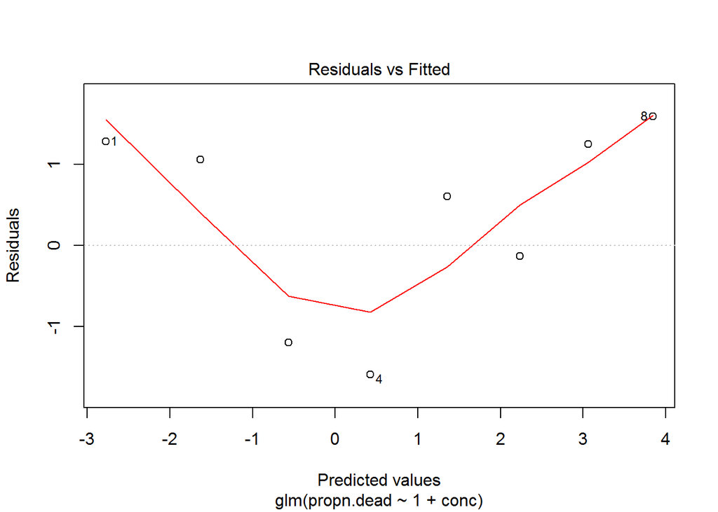

```r
plot(linear.glm,which = 1)
```

## Fitting quadratic model

```r
quad.glm <- glm(propn.dead ~ 1 +conc+ I(conc^2), binomial(logit), weights= number, data= beetle)
quad.glm
```

```
##
## Call:  glm(formula = propn.dead ~ 1 + conc + I(conc^2), family = binomial(logit),
##     data = beetle, weights = number)
##
## Coefficients:
## (Intercept)         conc    I(conc^2)
##       431.1       -520.6        156.4
##
## Degrees of Freedom: 7 Total (i.e. Null);  5 Residual
## Null Deviance:       284.2
## Residual Deviance: 3.195     AIC: 35.39
```

## Change in deviance

```r
linear.glm$deviance - quad.glm$deviance
```

```
## [1] 8.037326
```

```r
qchisq(0.95,1)
```

```
## [1] 3.841459
```

```r
qchisq(0.95,5)
```

```
## [1] 11.0705
```

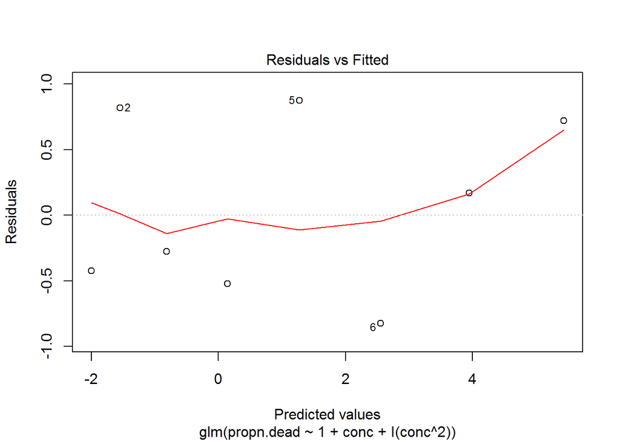

```r
plot(quad.glm,which = 1)
```

## 10 Wald t-test

```r
summary(quad.glm)
```

```
##
## Call:
## glm(formula = propn.dead ~ 1 + conc + I(conc^2), family = binomial(logit),
##     data = beetle, weights = number)
##
## Deviance Residuals:
##       1        2        3        4        5        6        7        8
## -0.4215   0.8189  -0.2769  -0.5232   0.8746  -0.8249   0.1698   0.7224
##
## Coefficients:
##             Estimate Std. Error z value Pr(>|z|)
## (Intercept)   431.11     180.65   2.386  0.01702 *
## conc         -520.62     204.52  -2.546  0.01091 *
## I(conc^2)     156.41      57.86   2.703  0.00687 **
## ---
## Signif. codes:  0 '***' 0.001 '**' 0.01 '*' 0.05 '.' 0.1 ' ' 1
##
## (Dispersion parameter for binomial family taken to be 1)
##
##     Null deviance: 284.2024  on 7  degrees of freedom
## Residual deviance:   3.1949  on 5  degrees of freedom
## AIC: 35.393
##
## Number of Fisher Scoring iterations: 4
```

```r
2*pnorm(-156.41/57.86)
```

```
## [1] 0.006866524
```

# 4.4.2

```r
anova(linear.glm, quad.glm,test="Chi")
```

```
## Analysis of Deviance Table
##
## Model 1: propn.dead ~ 1 + conc
## Model 2: propn.dead ~ 1 + conc + I(conc^2)
##   Resid. Df Resid. Dev Df Deviance Pr(>Chi)
## 1         6    11.2322
## 2         5     3.1949  1   8.0373 0.004582 **
## ---
## Signif. codes:  0 '***' 0.001 '**' 0.01 '*' 0.05 '.' 0.1 ' ' 1
```

# 4.4.3

$AIC = -2l + 2p$

$\frac{l_{min} - l_{mod}}{l_{min}}$

```r
quad.glm$aic
```

```
## [1] 35.39294
```

```r
l_mod<-length(quad.glm$coefficients) - 0.5*quad.glm$aic
l_min<-length(null.glm$coefficients) - 0.5*null.glm$aic
(l_min-l_mod)/l_min
```

```
## [1] 0.9053064
```

# 4.4.4 Calculating residuals for the beetle quadratic model

```r
residuals(quad.glm,type = "pearson")
```

```
##          1          2          3          4          5          6
## -0.4122545  0.8425072 -0.2754990 -0.5238566  0.8516013 -0.8716078
##          7          8
##  0.1654446  0.5113471
```

```r
y=beetle$propn.dead
fitted = quad.glm$fitted
n = beetle$number
```

Lets define function:

```r
pearson_resid <- function(y, fitted, n){
  (y-fitted)/sqrt(fitted * (1-fitted)/n)
}
```

and run it:

```r
pearson_resid(y, fitted, n)
```

```
##          1          2          3          4          5          6
## -0.4122545  0.8425072 -0.2754990 -0.5238566  0.8516013 -0.8716078
##          7          8
##  0.1654446  0.5113471
```

Other residuals are available:

Def function to compute $d_i$ deviance residuals:

```r
d_i_deviance <- function(y, fitted, n){
  sign(y- fitted)*sqrt(-2*n*(y*log(fitted/y)+(1-y)*log((1-fitted)/(1-y+0.0000001))))
}

d_i_deviance(y, fitted, n)
```

```
##          1          2          3          4          5          6
## -0.4215475  0.8189611 -0.2769161 -0.5232272  0.8746384 -0.8249153
##          7          8
##  0.1698457  0.7223680
```

compare with r computed values

```r
residuals(quad.glm,type="deviance")
```

```
##          1          2          3          4          5          6
## -0.4215335  0.8189537 -0.2768937 -0.5232165  0.8746312 -0.8249082
##          7          8
##  0.1698092  0.7223680
```

# Task 12

```r
residuals(linear.glm, "pearson")[1]
```

```
##        1
## 1.409296
```

```r
residuals(linear.glm, "deviance")[1]
```

```
##        1
## 1.283678
```

```r
linear.glm$fitted.values[1]
```

```
##          1
## 0.05860103
```

```r
pearson_resid(linear.glm$y, linear.glm$fitted.values, linear.glm$prior.weights)
```

```
##          1          2          3          4          5          6
##  1.4092960  1.1011003 -1.1762596 -1.6123815  0.5944454 -0.1281090
##          7          8
##  1.0914228  1.1331102
```

```r
d_i_deviance(linear.glm$y, linear.glm$fitted.values, linear.glm$prior.weights)
```

```
##          1          2          3          4          5          6
##  1.2836823  1.0596957 -1.1961175 -1.5941279  0.6061509 -0.1272048
##          7          8
##  1.2510760  1.5939850
```

# 4.4.5 Example 2 of model building : plant anthers

```r
anthers <- e$anthers
```

# Plot data

```r
head(anthers)
```

```
##       group force prepared obtained
## 1   control    40      102       55
## 2   control   150       99       52
## 3   control   350      108       57
## 4 treatment    40       76       55
## 5 treatment   150       81       50
## 6 treatment   350       90       50
```

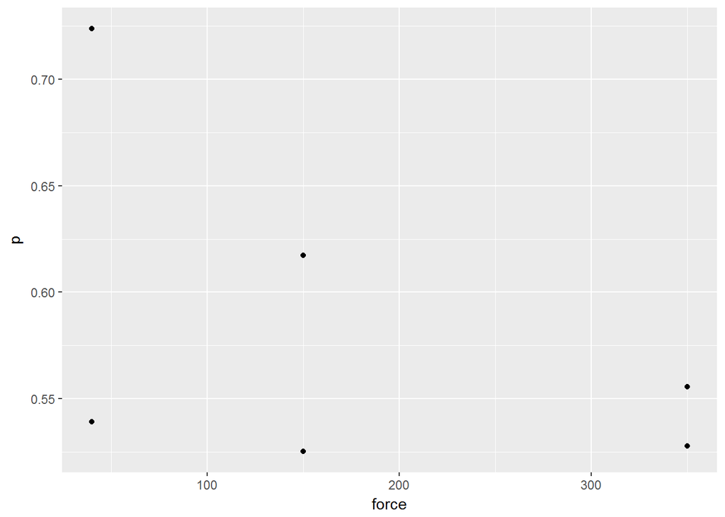

```r
anthers$p <- anthers$obtained/anthers$prepared

library(ggplot2)

ggplot(anthers, aes(force,p), colour= group) + geom_point()
```

## 2 consider logit link

```r
logit_link <- function(s,n){
  y <- (s + 1/2)/(n+1)
  log(y/(1-y))
}
```

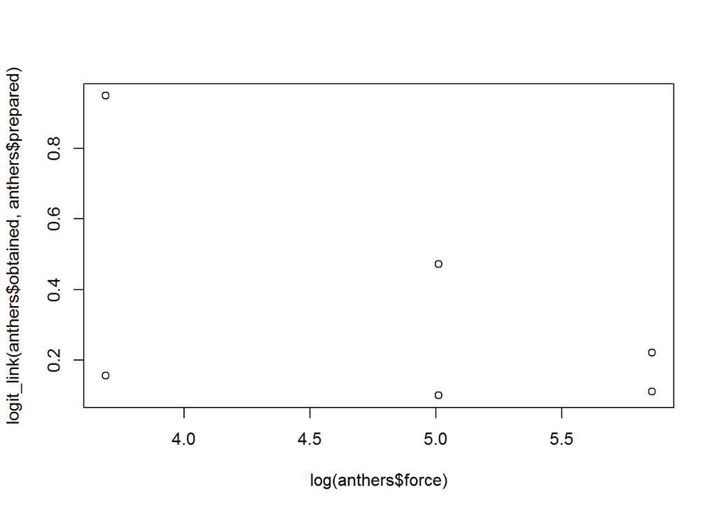

```r
plot(log(anthers$force),logit_link(anthers$obtained,anthers$prepared))
```

## Minimal Model

```r
glm.0 <-glm(p ~ 1, weights = prepared, data = anthers, binomial(logit))
summary(glm.0)
```

```
##
## Call:
## glm(formula = p ~ 1, family = binomial(logit), data = anthers,
##     weights = prepared)
##
## Deviance Residuals:
##       1        2        3        4        5        6
## -0.7029  -0.9716  -0.9622   2.7078   0.7965  -0.3483
##
## Coefficients:
##             Estimate Std. Error z value Pr(>|z|)
## (Intercept)  0.29713    0.08576   3.465 0.000531 ***
## ---
## Signif. codes:  0 '***' 0.001 '**' 0.01 '*' 0.05 '.' 0.1 ' ' 1
##
## (Dispersion parameter for binomial family taken to be 1)
##
##     Null deviance: 10.452  on 5  degrees of freedom
## Residual deviance: 10.452  on 5  degrees of freedom
## AIC: 42.02
##
## Number of Fisher Scoring iterations: 3
```

## Model 1

$\eta = \alpha$. Dobson is referenced, to make the lecture notes more confusing model 1 in Dobson is model 3 in notes.

```r
anthers$p <- anthers$obtained/anthers$prepared
anthers$logForce <- log(anthers$force)
glm.1 <-glm(p ~ group, weights = prepared, data = anthers, family = binomial(logit))
summary(glm.1)
```

```
##
## Call:
## glm(formula = p ~ group, family = binomial(logit), data = anthers,
##     weights = prepared)
##
## Deviance Residuals:
##        1         2         3         4         5         6
##  0.17150  -0.10947  -0.06177   1.77208  -0.19040  -1.39686
##
## Coefficients:
##                Estimate Std. Error z value Pr(>|z|)
## (Intercept)      0.1231     0.1140   1.080   0.2801
## grouptreatment   0.3985     0.1741   2.289   0.0221 *
## ---
## Signif. codes:  0 '***' 0.001 '**' 0.01 '*' 0.05 '.' 0.1 ' ' 1
##
## (Dispersion parameter for binomial family taken to be 1)
##
##     Null deviance: 10.452  on 5  degrees of freedom
## Residual deviance:  5.173  on 4  degrees of freedom
## AIC: 38.741
##
## Number of Fisher Scoring iterations: 3
```

```r
summary.lm(glm.1)
```

```
##
## Call:
## glm(formula = p ~ group, family = binomial(logit), data = anthers,
##     weights = prepared)
##
## Weighted Residuals:
##        1        2        3        4        5        6
##  0.17144 -0.10949 -0.06178  1.73385 -0.19074 -1.41234
##
## Coefficients:
##                Estimate Std. Error t value Pr(>|t|)
## (Intercept)      0.1231     0.1285   0.958    0.392
## grouptreatment   0.3985     0.1963   2.030    0.112
##
## Residual standard error: 1.127 on 4 degrees of freedom
## Multiple R-squared:  0.05731,    Adjusted R-squared:  -0.1784
## F-statistic: 0.2432 on 1 and 4 DF,  p-value: 0.6478
```

## Model 2

```r
anthers$p <- anthers$obtained/anthers$prepared
anthers$logForce <- log(anthers$force)
glm.2 <-glm(p ~ group + logForce, weights = prepared, data = anthers, family = binomial(logit))
summary(glm.2)
```

```
##
## Call:
## glm(formula = p ~ group + logForce, family = binomial(logit),
##     data = anthers, weights = prepared)
##
## Deviance Residuals:
##        1         2         3         4         5         6
## -0.74964  -0.00509   0.72746   0.99006  -0.13512  -0.72744
##
## Coefficients:
##                Estimate Std. Error z value Pr(>|z|)
## (Intercept)     0.87673    0.48701   1.800   0.0718 .
## grouptreatment  0.40684    0.17462   2.330   0.0198 *
## logForce       -0.15459    0.09702  -1.593   0.1111
## ---
## Signif. codes:  0 '***' 0.001 '**' 0.01 '*' 0.05 '.' 0.1 ' ' 1
##
## (Dispersion parameter for binomial family taken to be 1)
##
##     Null deviance: 10.4520  on 5  degrees of freedom
## Residual deviance:  2.6188  on 3  degrees of freedom
## AIC: 38.187
##
## Number of Fisher Scoring iterations: 3
```

```r
summary.lm(glm.2)
```

```
##
## Call:
## glm(formula = p ~ group + logForce, family = binomial(logit),
##     data = anthers, weights = prepared)
##
## Weighted Residuals:
##         1         2         3         4         5         6
## -0.752149 -0.005092  0.727404  0.975233 -0.135287 -0.730611
##
## Coefficients:
##                Estimate Std. Error t value Pr(>|t|)
## (Intercept)     0.87673    0.45321   1.934   0.1485
## grouptreatment  0.40684    0.16250   2.504   0.0874 .
## logForce       -0.15459    0.09029  -1.712   0.1854
## ---
## Signif. codes:  0 '***' 0.001 '**' 0.01 '*' 0.05 '.' 0.1 ' ' 1
##
## Residual standard error: 0.9306 on 3 degrees of freedom
## Multiple R-squared:  0.1477, Adjusted R-squared:  -0.4204
## F-statistic:  0.26 on 2 and 3 DF,  p-value: 0.7868
```

## Model 3

```r
lapply(anthers, class)
```

```
## $group
## [1] "factor"
##
## $force
## [1] "integer"
##
## $prepared
## [1] "integer"
##
## $obtained
## [1] "integer"
##
## $p
## [1] "numeric"
##
## $logForce
## [1] "numeric"
```

```r
glm.3 <-glm(p ~ group * logForce , weights = prepared, data = anthers, family = binomial(logit))
summary(glm.3)
```

```
##
## Call:
## glm(formula = p ~ group * logForce, family = binomial(logit),
##     data = anthers, weights = prepared)
##
## Deviance Residuals:
##        1         2         3         4         5         6
##  0.03611  -0.09370   0.05466   0.04305  -0.09855   0.05560
##
## Coefficients:
##                         Estimate Std. Error z value Pr(>|z|)
## (Intercept)              0.23389    0.62839   0.372   0.7097
## grouptreatment           1.97711    0.99802   1.981   0.0476 *
## logForce                -0.02274    0.12685  -0.179   0.8577
## grouptreatment:logForce -0.31862    0.19888  -1.602   0.1091
## ---
## Signif. codes:  0 '***' 0.001 '**' 0.01 '*' 0.05 '.' 0.1 ' ' 1
##
## (Dispersion parameter for binomial family taken to be 1)
##
##     Null deviance: 10.451974  on 5  degrees of freedom
## Residual deviance:  0.027728  on 2  degrees of freedom
## AIC: 37.596
##
## Number of Fisher Scoring iterations: 3
```

## Task 13

```r
glm.1 <-glm(p ~ group, weights = prepared, data = anthers, family = binomial(logit))
glm.1
```

```
##
## Call:  glm(formula = p ~ group, family = binomial(logit), data = anthers,
##     weights = prepared)
##
## Coefficients:
##    (Intercept)  grouptreatment
##         0.1231          0.3985
##
## Degrees of Freedom: 5 Total (i.e. Null);  4 Residual
## Null Deviance:       10.45
## Residual Deviance: 5.173     AIC: 38.74
```

```r
glm.2 <-glm(p ~ group + force, weights = prepared, data = anthers, family = binomial(logit))
glm.2
```

```
##
## Call:  glm(formula = p ~ group + force, family = binomial(logit), data = anthers,
##     weights = prepared)
##
## Coefficients:
##    (Intercept)  grouptreatment           force
##       0.306643        0.405554       -0.000997
##
## Degrees of Freedom: 5 Total (i.e. Null);  3 Residual
## Null Deviance:       10.45
## Residual Deviance: 2.922     AIC: 38.49
```

The conclusions do not change at all. The residual deviance for both models are rather similar.

# 4.5.1 (Task 14)

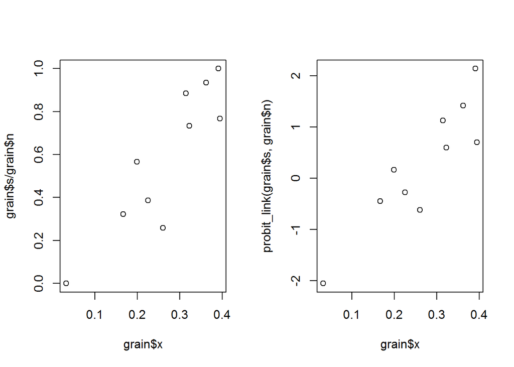

```r
grain <- e$grain



probit_link<- function(s,n){
  y<-(s+0.5)/(n+1)
  (qnorm(y))
}

par(mfrow=c(1,2))
plot(grain$x, grain$s/ grain$n)
plot(grain$x, probit_link(grain$s, grain$n))
```

```r
head(grain)
```

```
##       x  n  s
## 1 0.394 30 23
## 2 0.391 30 30
## 3 0.362 31 29
## 4 0.322 30 22
## 5 0.314 26 23
## 6 0.260 27  7
```

```r
grain$p_star <- (grain$s + 0.5)/ (grain$n+1)
grain$p <- (grain$s)/ (grain$n)
```

## 2 Null deviance

```r
glm(p ~ 1 , weights = grain$n, data= grain, family=binomial(link= 'probit'))
```

```
##
## Call:  glm(formula = p ~ 1, family = binomial(link = "probit"), data = grain,
##     weights = grain$n)
##
## Coefficients:
## (Intercept)
##      0.2444
##
## Degrees of Freedom: 9 Total (i.e. Null);  9 Residual
## Null Deviance:       138
## Residual Deviance: 138   AIC: 167.6
```

Can reproduce results from script only with p_start. But so far we only fitted models with $p = s/n$. Using `p_star` also produces a warning

```r
#glm(p_star ~ 1 + x , weights = grain$n, data= grain, family=binomial(link= 'probit'))
glin <- glm(p ~ 1 + x , weights = grain$n, data= grain, family=binomial(link= 'probit'))
names(glin)
```

```
##  [1] "coefficients"      "residuals"         "fitted.values"
##  [4] "effects"           "R"                 "rank"
##  [7] "qr"                "family"            "linear.predictors"
## [10] "deviance"          "aic"               "null.deviance"
## [13] "iter"              "weights"           "prior.weights"
## [16] "df.residual"       "df.null"           "y"
## [19] "converged"         "boundary"          "model"
## [22] "call"              "formula"           "terms"
## [25] "data"              "offset"            "control"
## [28] "method"            "contrasts"         "xlevels"
```

```r
glin$deviance
```

```
## [1] 35.47649
```

```r
glin$null.deviance
```

```
## [1] 138.0006
```

```r
glin$null.deviance-glin$deviance
```

```
## [1] 102.5241
```

But the actual deviance for the model is high 35.4764889 providing evidence against this Binomial model

$\chi^2_{8,0.9995}$ :

```r
qchisq(0.9995,8 )
```

```
## [1] 27.86805
```

## 5

Binomial model estimating $\phi$ as $D(y,\hat{\mu})/(n-p)$.

```r
glin$deviance / (glin$df.residual)
```

```
## [1] 4.434561
```

```r
glq <- glm(p ~ 1 + x , weights = grain$n, data= grain, family=quasi)
glq$deviance
```

```
## [1] 5.633424
```

```r
glq <- glm(p ~ 1 + x , weights = grain$n, data= grain, family=quasi(link = "identity", variance="constant"))
glq$deviance
```

```
## [1] 5.633424
```

```r
#this code fails
#glq <- glm(p ~ 1 + x , weights = grain$n, data= grain, family=quasi(link = "probit", variance="constant"))
grain$x
```

```
##  [1] 0.394 0.391 0.362 0.322 0.314 0.260 0.225 0.199 0.167 0.033
```

## 6

Standard errors for parameter estimates are then multiplied by:

```r
sqrt(glin$deviance / glin$df.residual)
```

```
## [1] 2.10584
```

## 7

Improvement over the null model on 1 df.

```r
(glin$null.deviance-glin$deviance)/ (glin$deviance / glin$df.residual)
```

```
## [1] 23.11934
```

The scaled deviance for this model:

```r
glin$deviance/(glin$deviance / glin$df.residual)
```

```
## [1] 8
```

```r
qchisq(0.95,7)
```

```
## [1] 14.06714
```

```r
sglin <- summary(glin)
```

with $e.s.e(\hat{\beta_1})=$

```r
sglin$coefficients[2,"Std. Error"]
```

```
## [1] 0.9810898
```

```r
sglin$coefficients[2,"Std. Error"] * sqrt(glin$deviance / glin$df.residual)
```

```
## [1] 2.066018
```

```r
ese_b=sglin$coefficients[2,"Std. Error"] * sqrt(glin$deviance / glin$df.residual)
```

So the Wald test statistics

```r
coefficients(glin)[2]
```

```
##        x
## 8.641606
```

```r
coefficients(glin)[2] / ese_b
```

```
##        x
## 4.182735
```

```r
t = coefficients(glin)[2] / ese_b
```

The slope is highly significant.

```r
1-pt(t, df=7)
```

```
##          x
## 0.00206159
```

## using quasi (same as subsection 5)

```r
glq <- glm(p_star ~ 1 + x , weights = grain$n, data= grain, family=quasi())
glq$deviance
```

```
## [1] 5.254139
```

Somehow the numbers obtained are not equal to those in the lecture notes (3.62): Also trying to run the `glm` with `quasi(link = "probit", variance = "constant")` does fail.

# 4.6

120 individuals collected as part of a case-control study:

```r
CHD <- e$CHD
head(CHD)
```

```
##   status sat.fat gender age
## 1      1       2      1  48
## 2      1       1      1  58
## 3      0       0      0  49
## 4      1       1      0  47
## 5      0       1      0  46
## 6      1       2      0  47
```

```r
null.glm<-glm(status~1, family=binomial,data=CHD)

gender.glm<-glm(status~gender,family=binomial,data=CHD)
summary(gender.glm)
```

```
##
## Call:
## glm(formula = status ~ gender, family = binomial, data = CHD)
##
## Deviance Residuals:
##    Min      1Q  Median      3Q     Max
## -1.515  -1.163   0.874   0.874   1.192
##
## Coefficients:
##             Estimate Std. Error z value Pr(>|z|)
## (Intercept) -0.03509    0.26495  -0.132   0.8946
## gender       0.80056    0.37875   2.114   0.0345 *
## ---
## Signif. codes:  0 '***' 0.001 '**' 0.01 '*' 0.05 '.' 0.1 ' ' 1
##
## (Dispersion parameter for binomial family taken to be 1)
##
##     Null deviance: 162.30  on 119  degrees of freedom
## Residual deviance: 157.74  on 118  degrees of freedom
## AIC: 161.74
##
## Number of Fisher Scoring iterations: 4
```

```r
anova(gender.glm, null.glm,test="Chi")
```

```
## Analysis of Deviance Table
##
## Model 1: status ~ gender
## Model 2: status ~ 1
##   Resid. Df Resid. Dev Df Deviance Pr(>Chi)
## 1       118     157.74
## 2       119     162.30 -1  -4.5554  0.03282 *
## ---
## Signif. codes:  0 '***' 0.001 '**' 0.01 '*' 0.05 '.' 0.1 ' ' 1
```

Odds ratio for being affected by CHD in males compared to females is $e^{\hat{\beta_1}}$:

```r
exp(coefficients(gender.glm)[2])
```

```
##   gender
## 2.226786
```

## 4.6.2 $X_i$ is a factor with 3 levels

```r
head(CHD)
```

```
##   status sat.fat gender age
## 1      1       2      1  48
## 2      1       1      1  58
## 3      0       0      0  49
## 4      1       1      0  47
## 5      0       1      0  46
## 6      1       2      0  47
```

```r
unique(CHD$sat.fat)
```

```
## [1] 2 1 0
```

```r
satfat.glm<- glm(status~sat.fat,family=binomial,data=CHD)
summary(satfat.glm)
```

```
##
## Call:
## glm(formula = status ~ sat.fat, family = binomial, data = CHD)
##
## Deviance Residuals:
##     Min       1Q   Median       3Q      Max
## -1.7439  -1.0279   0.7023   0.9909   1.3346
##
## Coefficients:
##             Estimate Std. Error z value Pr(>|z|)
## (Intercept)  -0.3623     0.2970  -1.220  0.22251
## sat.fat       0.8181     0.2644   3.095  0.00197 **
## ---
## Signif. codes:  0 '***' 0.001 '**' 0.01 '*' 0.05 '.' 0.1 ' ' 1
##
## (Dispersion parameter for binomial family taken to be 1)
##
##     Null deviance: 162.30  on 119  degrees of freedom
## Residual deviance: 151.86  on 118  degrees of freedom
## AIC: 155.86
##
## Number of Fisher Scoring iterations: 4
```

```r
qchisq(0.995,satfat.glm$df.residual)
```

```
## [1] 161.3141
```

```r
anova(satfat.glm, null.glm,test="Chi")
```

```
## Analysis of Deviance Table
##
## Model 1: status ~ sat.fat
## Model 2: status ~ 1
##   Resid. Df Resid. Dev Df Deviance Pr(>Chi)
## 1       118     151.86
## 2       119     162.30 -1  -10.438 0.001234 **
## ---
## Signif. codes:  0 '***' 0.001 '**' 0.01 '*' 0.05 '.' 0.1 ' ' 1
```

## 4.6.3 $X_i$ is continous

```r
head(CHD)
```

```
##   status sat.fat gender age
## 1      1       2      1  48
## 2      1       1      1  58
## 3      0       0      0  49
## 4      1       1      0  47
## 5      0       1      0  46
## 6      1       2      0  47
```

```r
age.glm<- glm(status~age,family=binomial,data=CHD)
summary(age.glm)
```

```
##
## Call:
## glm(formula = status ~ age, family = binomial, data = CHD)
##
## Deviance Residuals:
##     Min       1Q   Median       3Q      Max
## -1.6543  -1.2462   0.8034   1.0269   1.4730
##
## Coefficients:
##             Estimate Std. Error z value Pr(>|z|)
## (Intercept) -2.20096    1.11289  -1.978   0.0480 *
## age          0.05459    0.02340   2.333   0.0196 *
## ---
## Signif. codes:  0 '***' 0.001 '**' 0.01 '*' 0.05 '.' 0.1 ' ' 1
##
## (Dispersion parameter for binomial family taken to be 1)
##
##     Null deviance: 162.30  on 119  degrees of freedom
## Residual deviance: 156.42  on 118  degrees of freedom
## AIC: 160.42
##
## Number of Fisher Scoring iterations: 4
```

```r
qchisq(0.995,age.glm$df.residual)
```

```
## [1] 161.3141
```

```r
qchisq(0.995,1)
```

```
## [1] 7.879439
```

```r
anova(age.glm, null.glm,test="Chi")
```

```
## Analysis of Deviance Table
##
## Model 1: status ~ age
## Model 2: status ~ 1
##   Resid. Df Resid. Dev Df Deviance Pr(>Chi)
## 1       118     156.42
## 2       119     162.30 -1  -5.8799  0.01531 *
## ---
## Signif. codes:  0 '***' 0.001 '**' 0.01 '*' 0.05 '.' 0.1 ' ' 1
```

## 4.6.4 Multiple explanatory variables

```r
colnames(CHD)
```

```
## [1] "status"  "sat.fat" "gender"  "age"
```

```r
gender.glm<-glm(status~gender+age ,family=binomial,data=CHD)
summary(gender.glm)
```

```
##
## Call:
## glm(formula = status ~ gender + age, family = binomial, data = CHD)
##
## Deviance Residuals:
##     Min       1Q   Median       3Q      Max
## -1.8323  -1.1603   0.7256   0.9596   1.5802
##
## Coefficients:
##             Estimate Std. Error z value Pr(>|z|)
## (Intercept) -2.59535    1.13704  -2.283   0.0225 *
## gender       0.80587    0.38835   2.075   0.0380 *
## age          0.05436    0.02347   2.317   0.0205 *
## ---
## Signif. codes:  0 '***' 0.001 '**' 0.01 '*' 0.05 '.' 0.1 ' ' 1
##
## (Dispersion parameter for binomial family taken to be 1)
##
##     Null deviance: 162.30  on 119  degrees of freedom
## Residual deviance: 152.03  on 117  degrees of freedom
## AIC: 158.03
##
## Number of Fisher Scoring iterations: 4
```

```r
coefficients(gender.glm)[2]
```

```
##    gender
## 0.8058682
```

Adjusting for age does not change the estimated odds ratio 2.2386393.

## 4.6.5 Computing the confidence interval

```r
qnorm(0.975)
```

```
## [1] 1.959964
```

```r
coef(summary(gender.glm))[, "Std. Error"]
```

```
## (Intercept)      gender         age
##  1.13704066  0.38835454  0.02346514
```

```r
coefficients(gender.glm)
```

```
## (Intercept)      gender         age
## -2.59534522  0.80586824  0.05435797
```

```r
coefficients(gender.glm) + qnorm(0.975) * coef(summary(gender.glm))[, "Std. Error"]
```

```
## (Intercept)      gender         age
##  -0.3667865   1.5670292   0.1003488
```

```r
coefficients(gender.glm) - qnorm(0.975) * coef(summary(gender.glm))[, "Std. Error"]
```

```
##  (Intercept)       gender          age
## -4.823903955  0.044707325  0.008367151
```

```r
exp(0.044707325)
```

```
## [1] 1.045722
```

```r
exp(1.5670292)
```

```
## [1] 4.79239
```